# Multiplier-Resampling Coverage Sweep

- Show All Code
- Hide All Code
- View Source

95% coverage of the marginal subgroup hazard ratio (C†) vs sample size, for the consistency / dina / grf detectors — León (2024) M1 design

Author

Larry León

Published

June 21, 2026

> **One document, one sweep.** This renders the entire `subgroup_method × n_sample` grid (3 methods × 7 sizes = 21 cells), writes one small results bundle per cell to `results_dir/`, accumulates them into a single coverage grid (`mr_coverage_grid.rds`), and plots C† coverage vs *n*. It is **resumable**: each cell is skipped if its bundle already exists, so you can run a subset today and the rest later and the grid fills in. Set `nb_boots <- NULL` (the default) for the MR-only run; the full-bootstrap (FB) path stays wired but dormant.

> **How to drive it.** 1. *Preliminary:* keep `n_sims` small and subset the sweep (`methods_run`, `n_grid_run`) to a cell or two; render; eyeball. 2. *Production:* bump `n_sims`, restore the full `methods_run` / `n_grid_run`, render. Finished cells are skipped; only new ones compute. 3. *Re-plot only:* set `run_sweep <- FALSE` to rebuild the grid and figures from existing bundles without running anything.

> To force a cell to recompute (e.g. after raising `n_sims`), delete its `*_res.rds` in `results_dir/`.

# 1 What this evaluates

For each cell — one `(subgroup_method, n_sample)` pair — the document runs `n_sims` simulated trials on the León (2024) GBSG-AFT M1 super-population, and on each detected replicate records the **MR** de-biased gate (`forestsearch(debias_gate = TRUE)`, infinitesimal-jackknife interval) together with the oracle and naive estimators. Coverage is the proportion of detected replicates whose 95% CI contains the target, computed against the **marginal subgroup hazard ratio** θ† (population, *n*-invariant). Because θ† and the other truth targets are properties of the fixed DGM, the DGM is built **once** and reused across every cell, so the coverage-vs-*n* curve compares like with like.

All coverage rates here are **conditional on detecting a subgroup**; the companion detection-rate panel is reported alongside so the curve is read in that light.

# 2 Setup — all knobs

```r
.t0_doc <- Sys.time()

# forestsearch must be INSTALLED (devtools::install()), not load_all(): the
# doFuture multisession workers spawn separate R processes that only see the
# installed package.
library(forestsearch)
library(survival)
library(data.table)
library(ggplot2)
library(foreach)
library(doFuture)
library(future)

# ── The sweep ────────────────────────────────────────────────────────────────
methods  <- c("consistency", "dina", "grf")     # detector axis
n_grid   <- seq(500L, 2000L, by = 250L)         # sample-size axis: 500..2000 by 250 (7)

# Subset these for a preliminary pass; restore to `methods` / `n_grid` for the
# full grid.  (Resumable either way — see the run-sweep chunk.)
methods_run <- methods                           # e.g. "consistency"
n_grid_run  <- n_grid                            # e.g. c(500L, 1000L)

# ── Counts (the main knobs for smoke → production) ───────────────────────────
n_sims    <- 1000L        # simulated trials per cell        (prod: 1000 → 20000)
nb_boots  <- NULL       # FB nonparametric bootstraps; NULL/0 ⇒ MR-only (FB dormant)
gate_draws <- 5000L     # MR multiplier draws              (keep ~2000–5000)
diag_mode <- FALSE      # TRUE caps each cell to 5 reps and surfaces forestsearch errors

# ── Run controls ─────────────────────────────────────────────────────────────
run_sweep   <- FALSE                       # FALSE ⇒ skip computation, just (re)build grid + plots
# run_tag identifies THIS run (DGM cell · sim count · draws · whatever distinguishes it).
# results_dir AND the grid filename both derive from it, so changing run_tag writes to a new
# folder and a new grid with NO pooling of prior runs — the clean way to get a fresh set.
# The figure fragment (_sim_mr_coverage.qmd) reads the grid by matching this SAME run_tag,
# so keep the two strings identical. Convention: <dgm>_s<n_sims>_d<gate_draws>.
run_tag     <- "m1_h15_knoise0_s1000" # ← bump this for a fresh, isolated run
results_dir <- file.path("mr_sweep", run_tag)   # per-run folder: bundles + grid live here
rds_tag     <- "fs_mr"                     # per-cell bundle stem (method + n appended)
grid_path   <- file.path(results_dir, sprintf("mr_coverage_grid_%s.rds", run_tag))

# ── Parallelization ──────────────────────────────────────────────────────────
# "sims"  -> replicates fan out across workers (each rep's search runs sequentially).
#            BEST for this MR-only sweep: no inner bootstrap, so filling cores with
#            replicates is the throughput win.
# "boots" -> replicates sequential; the search (and, if nb_boots>0, the bootstrap)
#            parallelize WITHIN each replicate.  Prefer only if a cell sets nb_boots>0
#            with small n_sims.
# All draws are explicitly seeded (seed_base + sim_id), so results are
# plan-invariant: the modes differ in wall-clock only.
parallel_mode <- "sims"
seed_base <- 8316951L
n_workers <- max(1L, ceiling(0.90 * (parallel::detectCores(logical = FALSE) - 1L)))
inner_parallel <- if (identical(parallel_mode, "boots"))
  list(plan = "multisession", workers = n_workers) else list(plan = "sequential")
z975 <- qnorm(0.975)

# ── DGM: León M1 cell (GBSG AFT super-population, alt hypothesis) ─────────────
dgm_model      <- "alt"
analysis_time  <- 84            # administrative censoring (months)
cens_adjust    <- log(1.5)
n_super        <- 25000L
target_hr_harm <- 1.0           # calibrate k_inter to this Cox HR in the harm subgroup
k_random_noise <- 0             # add k_random_noise standard-normal noise confounders

# ── Search configuration (León tuning; resample identification) ──────────────
consistency_method <- "resample"
sg_focus           <- "eff"     # consistency + "eff" ⇒ gate re-selection "maxcons"
selection_rule     <- "neighborhood"
hr_threshold   <- 0.90
hr_consistency <- 0.80
pconsistency   <- 0.90
fs_splits <- 400L; maxk <- 2L; n_min <- NULL; d0_min <- 10L; d1_min <- 0L
use_lasso <- FALSE; use_dina <- FALSE; use_grf <- FALSE; use_twostage <- TRUE
fs_conf_force      <- c("meno == 0", "er <= 0", "pgr <= 0")   # premenopausal (raw analog of z3 == 1)
fs_conf.cont_jcuts <- list(er = 10)                          # J-quantile grid on raw ER

# Method-specific selectors (only the matching block is used per cell).
grf_selection <- "frontier"; grf_select_statistic <- "effect"
grf_depth <- 2L; dmin.grf <- 0.0
dina_args <- list(); dina_select_statistic <- "effect"

# ── Column names emitted by simulate_from_dgm() ──────────────────────────────
outcome_name <- "y_sim"; event_name <- "event_sim"; treat_name <- "treat_sim"
id_name <- "id"; harm_col <- "flag_harm"
confounders_base <- c("er", "age", "meno", "pgr", "nodes", "size", "grade")

`%||%` <- function(a, b) if (is.null(a) || length(a) == 0 || all(is.na(a))) b else a

cat(sprintf("Sweep: %d method(s) × %d size(s) = %d cell(s) to consider.\n",
            length(methods_run), length(n_grid_run),
            length(methods_run) * length(n_grid_run)))
```

```
Sweep: 3 method(s) × 7 size(s) = 21 cell(s) to consider.
```

```r
cat(sprintf("Counts: n_sims=%d, nb_boots=%s (MR-only=%s), gate_draws=%d.\n",
            n_sims, if (is.null(nb_boots)) "NULL" else as.character(nb_boots),
            if (is.null(nb_boots) || identical(nb_boots, 0L)) "yes" else "no", gate_draws))
```

```
Counts: n_sims=1000, nb_boots=NULL (MR-only=yes), gate_draws=5000.
```

```r
cat(sprintf("Parallel: %s · %d workers · seed_base=%d.\n",
            parallel_mode, n_workers, seed_base))
```

```
Parallel: sims · 115 workers · seed_base=8316951.
```

# 3 Build the DGM once (n-invariant truth)

```r
dgm <- NULL; truth <- NULL
if (run_sweep) {
  k_inter <- calibrate_k_inter(target_hr_harm = target_hr_harm,
                               model = dgm_model, use_ahr = FALSE)
  dgm <- setup_gbsg_dgm(model = dgm_model, k_inter = k_inter,
                        n_super = n_super, seed = seed_base)
  dgm <- compute_dgm_cde(dgm)   # attaches CDE (θ‡) targets

  truth <- list(
    hr_causal = dgm$hr_causal  %||% NA_real_,                 # overall causal HR
    marg_H    = dgm$hr_H_true  %||% NA_real_,                 # θ†  (H)
    marg_Hc   = dgm$hr_Hc_true %||% NA_real_,                 # θ†  (Hc)
    cde_H     = dgm$cde_H  %||% (dgm$hazard_ratios$CDE_harm    %||% NA_real_),  # θ‡ (H)
    cde_Hc    = dgm$cde_Hc %||% (dgm$hazard_ratios$CDE_no_harm %||% NA_real_)   # θ‡ (Hc)
  )
  cat("DGM truth targets (population, shared by every cell):\n")
  cat(sprintf("  overall causal HR    : %.3f\n", truth$hr_causal))
  cat(sprintf("  θ†  (marginal)  H/Hc : %.3f / %.3f\n", truth$marg_H, truth$marg_Hc))
  cat(sprintf("  θ‡  (CDE)       H/Hc : %.3f / %.3f\n", truth$cde_H,  truth$cde_Hc))
} else {
  cat("run_sweep = FALSE: DGM build skipped (grid rebuilt from existing bundles).\n")
}
```

```
run_sweep = FALSE: DGM build skipped (grid rebuilt from existing bundles).
```

# 4 Per-replicate recorder

`record_replicate()` takes the cell axes (`method`, `n_sample`) explicitly and reads the fixed configuration from the setup chunk. Everything else mirrors the single-cell recorder: identify Ĥ + naive + MR gate in one `forestsearch()` call, optionally run the FB bootstrap (skipped when `nb_boots` is NULL/0), and refit the oracle on the true harm subgroup. A failure returns an all-NA record so the loop never aborts a cell.

```r
# Cox HR + delta-method 95% CI on a subset (the per-replicate oracle target).
# Guards separation: non-finite coef/SE returns a clean NA triple, not Inf bounds.
.cox_hr_ci <- function(df) {
  if (sum(df[[event_name]]) < 5L || length(unique(df[[treat_name]])) < 2L)
    return(c(est = NA_real_, lo = NA_real_, hi = NA_real_))
  fml <- stats::as.formula(sprintf("survival::Surv(%s, %s) ~ %s",
                                   outcome_name, event_name, treat_name))
  fit <- tryCatch(survival::coxph(fml, data = df), error = function(e) NULL)
  if (is.null(fit)) return(c(est = NA_real_, lo = NA_real_, hi = NA_real_))
  b <- unname(stats::coef(fit)[1])
  v <- unname(suppressWarnings(diag(stats::vcov(fit))[1]))
  se <- if (is.finite(v) && v > 0) sqrt(v) else NA_real_
  if (!is.finite(b) || !is.finite(se))
    return(c(est = NA_real_, lo = NA_real_, hi = NA_real_))
  c(est = exp(b), lo = exp(b - z975 * se), hi = exp(b + z975 * se))
}

# Classification of Ĥ vs the true harm flag.
.classify <- function(sg_hat, truth_flag) {
  out <- c(sens = NA_real_, spec = NA_real_, ppv = NA_real_, npv = NA_real_)
  if (is.null(sg_hat) || length(sg_hat) != length(truth_flag)) return(out)
  sg_hat <- as.integer(sg_hat); truth_flag <- as.integer(truth_flag)
  tp <- sum(sg_hat == 1 & truth_flag == 1); fp <- sum(sg_hat == 1 & truth_flag == 0)
  fn <- sum(sg_hat == 0 & truth_flag == 1); tn <- sum(sg_hat == 0 & truth_flag == 0)
  out["sens"] <- if (tp + fn > 0) tp / (tp + fn) else NA_real_
  out["spec"] <- if (tn + fp > 0) tn / (tn + fp) else NA_real_
  out["ppv"]  <- if (tp + fp > 0) tp / (tp + fp) else NA_real_
  out["npv"]  <- if (tn + fn > 0) tn / (tn + fn) else NA_real_
  out
}

# One all-NA record (returned on failure so the loop never aborts a cell).
.na_record <- function(sim_id) data.frame(
  sim_id = sim_id, detected = 0L, gate_ok = 0L, n_sel = NA_integer_,
  n_harm = NA_integer_, n_true = NA_integer_,
  label = NA_character_, t1_secs = NA_real_, t2_secs = NA_real_, t1_err = NA_character_,
  or_H_est = NA, or_H_lo = NA, or_H_hi = NA,
  or_Hc_est = NA, or_Hc_lo = NA, or_Hc_hi = NA,
  nv_H_est = NA, nv_H_lo = NA, nv_H_hi = NA,
  nv_Hc_est = NA, nv_Hc_lo = NA, nv_Hc_hi = NA,
  t1_H_est = NA, t1_H_lo = NA, t1_H_hi = NA,
  t1_Hc_est = NA, t1_Hc_lo = NA, t1_Hc_hi = NA,
  t2_H_est = NA, t2_H_lo = NA, t2_H_hi = NA, t2_H_se_ij = NA,
  t2_Hc_est = NA, t2_Hc_lo = NA, t2_Hc_hi = NA, t2_Hc_se_ij = NA,
  t2_harm_flag = NA_integer_, ij_source = NA_character_,
  sens = NA_real_, spec = NA_real_, ppv = NA_real_, npv = NA_real_,
  stringsAsFactors = FALSE)

record_replicate <- function(sim_id, method, n_sample, nb_boots) {
  run_tier1 <- is.numeric(nb_boots) && length(nb_boots) == 1L && nb_boots >= 1L
  rec <- .na_record(sim_id)

  df <- tryCatch(
    simulate_from_dgm(dgm, n = n_sample, analysis_time = analysis_time,
                      cens_adjust = cens_adjust, seed = seed_base + sim_id),
    error = function(e) NULL)
  if (is.null(df)) return(rec)
  df[[id_name]] <- seq_len(nrow(df))
  confs <- intersect(confounders_base, names(df))

  # Optional standard-normal noise confounders, seeded by sim_id (offset to stay
  # disjoint from the DGM seed) so the full replicate is a deterministic function
  # of sim_id, independent of batch/loop position.
  if (k_random_noise > 0) {
    noise_names <- paste0("noise", seq_len(k_random_noise))
    set.seed(seed_base + sim_id + 1000000L)
    for (nm in noise_names) df[[nm]] <- rnorm(nrow(df))
    confs <- c(confs, noise_names)
  }

  rec$n_true <- sum(df[[harm_col]] == 1L, na.rm = TRUE)

  # ---- Identification + naive + MR gate (single forestsearch call) ----------
  base_args <- list(
    df.analysis     = df,
    outcome.name    = outcome_name, event.name = event_name,
    treat.name      = treat_name,   id.name    = id_name,
    flag_harm.name  = harm_col,     confounders.name = confs,
    is.RCT          = TRUE,         seedit = seed_base + sim_id,
    quiet           = TRUE,
    sg_focus        = sg_focus,
    subgroup_method = method,
    hr.threshold    = hr_threshold, hr.consistency = hr_consistency,
    pconsistency.threshold = pconsistency, n.min = n_min,
    selection_rule  = selection_rule,
    parallel_args   = inner_parallel,
    debias_gate     = TRUE,
    debias_gate_args = list(ci_method = "ij", draws = gate_draws,
                            include_complement = TRUE))
  method_args <- switch(
    method,
    consistency = list(
      consistency_method = consistency_method,
      use_lasso = use_lasso, use_grf = use_grf, use_twostage = use_twostage,
      use_dina = use_dina, conf_force = fs_conf_force,
      conf.cont_jcuts = fs_conf.cont_jcuts,
      fs.splits = fs_splits, maxk = maxk, d0.min = d0_min, d1.min = d1_min),
    dina = list(dina_select_statistic = dina_select_statistic, dina_args = dina_args),
    grf  = list(grf_selection = grf_selection, grf_depth = grf_depth,
                dmin.grf = dmin.grf, grf_select_statistic = grf_select_statistic),
    stop("unknown subgroup_method: ", method))

  t2_t0 <- proc.time()[3]
  fs.est <- tryCatch(do.call(forestsearch, c(base_args, method_args)),
                     error = function(e) {
                       if (isTRUE(get0("diag_mode", ifnotfound = FALSE)))
                         warning(sprintf("FS-ERR sim %d (%s, n=%d): %s", sim_id,
                                         method, n_sample, conditionMessage(e)),
                                 call. = FALSE)
                       NULL })
  rec$t2_secs <- proc.time()[3] - t2_t0
  if (is.null(fs.est)) return(rec)

  g     <- fs.est$debias_gate
  found <- !is.null(fs.est$sg.harm)
  rec$detected <- as.integer(found)
  if (!found) return(rec)
  rec$gate_ok <- as.integer(!is.null(g))

  if (!is.null(g)) {
    rec$label <- g$selected_label %||% NA_character_
    rec$n_sel <- g$n_selected      %||% NA_integer_
    rec$t2_harm_flag <- as.integer(isTRUE(g$harm_flag))
    rec$ij_source    <- g$debiased$ij_source %||% NA_character_
    rec$nv_H_est <- g$naive$est;    rec$nv_H_lo <- g$naive$lower;    rec$nv_H_hi <- g$naive$upper
    rec$t2_H_est <- g$debiased$est; rec$t2_H_lo <- g$debiased$lower; rec$t2_H_hi <- g$debiased$upper
    rec$t2_H_se_ij <- g$debiased$se_ij %||% NA_real_
    if (is.list(g$complement) && !is.null(g$complement$debiased)) {
      rec$nv_Hc_est <- g$complement$naive$est
      rec$nv_Hc_lo  <- g$complement$naive$lower
      rec$nv_Hc_hi  <- g$complement$naive$upper
      rec$t2_Hc_est <- g$complement$debiased$est
      rec$t2_Hc_lo  <- g$complement$debiased$lower
      rec$t2_Hc_hi  <- g$complement$debiased$upper
      rec$t2_Hc_se_ij <- g$complement$debiased$se_ij %||% NA_real_
    }
  }

  cl <- .classify(fs.est$grp.consistency$sg.harm.id, df[[harm_col]])
  rec$sens <- cl["sens"]; rec$spec <- cl["spec"]; rec$ppv <- cl["ppv"]; rec$npv <- cl["npv"]
  rec$n_harm <- sum(fs.est$grp.consistency$sg.harm.id == 1L, na.rm = TRUE)

  # ---- FB bootstrap (H2 = León Eq.7) — dormant when nb_boots NULL/0 ----------
  if (run_tier1 && method %in% c("consistency", "dina", "grf")) {
    t1_t0 <- proc.time()[3]; t1_err <- NA_character_
    boot <- tryCatch(
      forestsearch_bootstrap_dofuture(fs.est, nb_boots = nb_boots,
                                      seed = seed_base + sim_id,
                                      parallel_args = inner_parallel),
      error = function(e) { t1_err <<- conditionMessage(e); NULL })
    rec$t1_secs <- proc.time()[3] - t1_t0
    rec$t1_err  <- t1_err
    if (!is.null(boot) && !is.null(boot$H_estimates)) {
      he <- boot$H_estimates
      rec$t1_H_est <- he$H2 %||% NA_real_
      rec$t1_H_lo  <- he$H2_lower %||% NA_real_
      rec$t1_H_hi  <- he$H2_upper %||% NA_real_
    }
    if (!is.null(boot) && !is.null(boot$Hc_estimates)) {
      hce <- boot$Hc_estimates
      rec$t1_Hc_est <- hce$H2 %||% NA_real_
      rec$t1_Hc_lo  <- hce$H2_lower %||% NA_real_
      rec$t1_Hc_hi  <- hce$H2_upper %||% NA_real_
    }
  }

  # ---- Oracle: refit on the TRUE harm subgroup of this trial ----------------
  oH  <- .cox_hr_ci(df[df[[harm_col]] == 1, , drop = FALSE])
  oHc <- .cox_hr_ci(df[df[[harm_col]] == 0, , drop = FALSE])
  rec$or_H_est  <- oH["est"];  rec$or_H_lo  <- oH["lo"];  rec$or_H_hi  <- oH["hi"]
  rec$or_Hc_est <- oHc["est"]; rec$or_Hc_lo <- oHc["lo"]; rec$or_Hc_hi <- oHc["hi"]

  rec
}
```

# 5 `run_cell()` — one (method, n) → one bundle

```r
# Runs `n_sims` replicates for one cell and returns (and optionally writes) the
# bundle list(results, truth, meta) — exactly the structure the original
# single-cell doc saved, so downstream readers (and the per-cell León-Table view
# in _sim_estimation_fs_*.qmd) consume it unchanged.
run_cell <- function(method, n_sample, nb_boots = NULL, out = NULL,
                     sim_id_start = 1L) {
  sim_ids <- sim_id_start:(sim_id_start + n_sims - 1L)
  if (isTRUE(diag_mode)) sim_ids <- utils::head(sim_ids, 5L)

  t0 <- proc.time()[3]
  if (identical(parallel_mode, "sims")) {
    plan("sequential"); gc(); plan("multisession", workers = n_workers)
    results <- foreach(
      s = sim_ids, .combine = rbind, .errorhandling = "remove",
      .options.future = list(packages = c("forestsearch", "survival", "data.table"),
                             seed = TRUE)
    ) %dofuture% record_replicate(s, method, n_sample, nb_boots)
    plan("sequential"); gc()
  } else {
    plan("sequential"); gc()
    results <- do.call(rbind, lapply(sim_ids, function(s)
      tryCatch(record_replicate(s, method, n_sample, nb_boots), error = function(e) NULL)))
    plan("sequential"); gc()
  }
  elapsed <- proc.time()[3] - t0
  if (is.null(results) || !nrow(results)) results <- .na_record(0L)[0, , drop = FALSE]

  bundle <- list(
    results = results, truth = truth,
    meta = list(n_sample = n_sample, n_sims = n_sims, nb_boots = nb_boots,
                gate_draws = gate_draws, subgroup_method = method,
                sim_id_start = sim_id_start, sim_id_end = max(sim_ids),
                seed_base = seed_base, parallel_mode = parallel_mode,
                elapsed_sec = elapsed))
  if (!is.null(out)) saveRDS(bundle, out)
  bundle
}
```

# 6 Coverage post-processing helpers (inlined)

```r
.EST_KEYS   <- c(oracle = "or", naive = "nv", FB = "t1", MR = "t2")
.TARGET_COL <- c(oracle = "C_oracle", cde = "C_ddagger", marg = "C_dagger")

# Coverage + uncertainty for one (target, lo, hi) triple.  The finite-only mask
# reproduces the original .cover() exactly; n_eff / mc_se / Wilson are additions.
.coverage_meta <- function(target, lo, hi, conf = 0.95) {
  n <- length(lo); target <- rep_len(target, n)
  ok <- is.finite(target) & is.finite(lo) & is.finite(hi)
  n_eff <- sum(ok)
  if (n_eff == 0L)
    return(data.frame(coverage = NA_real_, n_eff = 0L, n_cov = NA_integer_,
                      mc_se = NA_real_, wilson_lo = NA_real_, wilson_hi = NA_real_))
  hit <- target[ok] >= lo[ok] & target[ok] <= hi[ok]
  k <- sum(hit); p <- k / n_eff
  mc_se <- sqrt(p * (1 - p) / n_eff)
  z <- stats::qnorm(1 - (1 - conf) / 2)
  den <- 1 + z^2 / n_eff
  ctr <- (p + z^2 / (2 * n_eff)) / den
  hw  <- (z / den) * sqrt(p * (1 - p) / n_eff + z^2 / (4 * n_eff^2))
  data.frame(coverage = p, n_eff = n_eff, n_cov = k, mc_se = mc_se,
             wilson_lo = max(0, ctr - hw), wilson_hi = min(1, ctr + hw))
}

# CI length (HR scale, hi - lo) for one (estimator, block); target-independent, so
# summarised once per (method, n, block, estimator) rather than per coverage target.
# Median is the headline (robust to the occasional IJ blow-up); IQR carries spread.
.length_meta <- function(lo, hi) {
  len <- hi - lo; len <- len[is.finite(len)]
  if (!length(len))
    return(data.frame(len_med = NA_real_, len_mean = NA_real_,
                      len_q25 = NA_real_, len_q75 = NA_real_, n_len = 0L))
  q <- stats::quantile(len, c(0.25, 0.75), names = FALSE, type = 7)
  data.frame(len_med = stats::median(len), len_mean = mean(len),
             len_q25 = q[1], len_q75 = q[2], n_len = length(len))
}

# One bundle (path or list) → tidy one-row-per (method, n, block, estimator, target).
coverage_from_bundle <- function(bundle,
                                 estimators = c("oracle", "naive", "MR"),
                                 blocks = c("H", "Hc"),
                                 targets = c("marg", "cde"),
                                 drop_all_na = TRUE, src = NULL) {
  if (is.character(bundle)) {
    stopifnot(file.exists(bundle)); if (is.null(src)) src <- basename(bundle)
    bundle <- readRDS(bundle)
  }
  if (is.null(src)) src <- NA_character_
  res <- bundle$results; tr <- bundle$truth; meta <- bundle$meta
  stopifnot(is.data.frame(res), is.list(tr), is.list(meta))
  rH <- res[res$detected == 1L, , drop = FALSE]

  rows <- list()
  for (blk in blocks) {
    tgt_val <- list(oracle = rH[[paste0("or_", blk, "_est")]],
                    cde    = tr[[paste0("cde_",  blk)]],
                    marg   = tr[[paste0("marg_", blk)]])
    for (est in estimators) {
      k  <- .EST_KEYS[[est]]
      lo <- rH[[paste0(k, "_", blk, "_lo")]]; hi <- rH[[paste0(k, "_", blk, "_hi")]]
      for (tg in targets) {
        cm <- .coverage_meta(tgt_val[[tg]], lo, hi)
        rows[[length(rows) + 1L]] <- cbind(
          data.frame(subgroup_method = meta$subgroup_method %||% NA_character_,
                     n_sample = meta$n_sample %||% NA_integer_,
                     block = blk, estimator = est,
                     target = unname(.TARGET_COL[[tg]]), stringsAsFactors = FALSE),
          cm,
          data.frame(n_sims = meta$n_sims %||% NA_integer_, n_detected = nrow(rH),
                     det_rate = if (nrow(res)) mean(res$detected, na.rm = TRUE) else NA_real_,
                     gate_draws = meta$gate_draws %||% NA_integer_,
                     nb_boots = meta$nb_boots %||% NA_integer_,
                     seed_base = meta$seed_base %||% NA_integer_, src = src,
                     stringsAsFactors = FALSE))
      }
    }
  }
  df <- do.call(rbind, rows)
  if (isTRUE(drop_all_na)) df <- df[!is.na(df$coverage), , drop = FALSE]
  rownames(df) <- NULL; df
}

# One bundle -> tidy one-row-per (method, n, block, estimator) CI-length summary.
length_from_bundle <- function(bundle, estimators = c("oracle", "naive", "MR"),
                               blocks = c("H", "Hc"), src = NULL) {
  if (is.character(bundle)) {
    stopifnot(file.exists(bundle)); if (is.null(src)) src <- basename(bundle)
    bundle <- readRDS(bundle)
  }
  if (is.null(src)) src <- NA_character_
  res <- bundle$results; meta <- bundle$meta
  stopifnot(is.data.frame(res), is.list(meta))
  rH <- res[res$detected == 1L, , drop = FALSE]
  rows <- list()
  for (blk in blocks) for (est in estimators) {
    k  <- .EST_KEYS[[est]]
    lm <- .length_meta(rH[[paste0(k, "_", blk, "_lo")]], rH[[paste0(k, "_", blk, "_hi")]])
    rows[[length(rows) + 1L]] <- cbind(
      data.frame(subgroup_method = meta$subgroup_method %||% NA_character_,
                 n_sample = meta$n_sample %||% NA_integer_,
                 block = blk, estimator = est, stringsAsFactors = FALSE),
      lm,
      data.frame(n_sims = meta$n_sims %||% NA_integer_,
                 gate_draws = meta$gate_draws %||% NA_integer_,
                 nb_boots = meta$nb_boots %||% NA_integer_, src = src,
                 stringsAsFactors = FALSE))
  }
  df <- do.call(rbind, rows); rownames(df) <- NULL; df
}

# Bias of an estimate vs a target, on the log-HR scale (mean log(est/target)) and the
# HR scale (mean(est - target)), each with its Monte-Carlo SE.  HRs are positive, so the
# log is well-defined; any non-positive/non-finite pair is dropped.
.bias_meta <- function(est, target) {
  n <- length(est); target <- rep_len(target, n)
  ok <- is.finite(est) & is.finite(target) & est > 0 & target > 0
  m  <- sum(ok)
  if (m == 0L)
    return(data.frame(bias_log = NA_real_, se_log = NA_real_, bias_hr = NA_real_,
                      se_hr = NA_real_, bias_rel = NA_real_, se_rel = NA_real_, n_bias = 0L))
  d_log <- log(est[ok]) - log(target[ok])
  d_hr  <- est[ok] - target[ok]
  d_rel <- 100 * (est[ok] - target[ok]) / target[ok]   # per-replicate % bias over the target
  .se <- function(x) if (length(x) > 1L) stats::sd(x) / sqrt(length(x)) else NA_real_
  data.frame(bias_log = mean(d_log), se_log = .se(d_log),
             bias_hr  = mean(d_hr),  se_hr  = .se(d_hr),
             bias_rel = mean(d_rel), se_rel = .se(d_rel), n_bias = m)
}

# One bundle -> tidy one-row-per (method, n, block, estimator, target) bias summary.
# Bias depends on the target (unlike CI length), so it carries the target column.
bias_from_bundle <- function(bundle, estimators = c("oracle", "naive", "MR"),
                             blocks = c("H", "Hc"), targets = c("marg", "cde"),
                             drop_all_na = TRUE, src = NULL) {
  if (is.character(bundle)) {
    stopifnot(file.exists(bundle)); if (is.null(src)) src <- basename(bundle)
    bundle <- readRDS(bundle)
  }
  if (is.null(src)) src <- NA_character_
  res <- bundle$results; tr <- bundle$truth; meta <- bundle$meta
  stopifnot(is.data.frame(res), is.list(tr), is.list(meta))
  rH <- res[res$detected == 1L, , drop = FALSE]
  rows <- list()
  for (blk in blocks) {
    tgt_val <- list(oracle = rH[[paste0("or_", blk, "_est")]],
                    cde    = tr[[paste0("cde_",  blk)]],
                    marg   = tr[[paste0("marg_", blk)]])
    for (est in estimators) {
      k  <- .EST_KEYS[[est]]
      ev <- rH[[paste0(k, "_", blk, "_est")]]
      for (tg in targets) {
        bm <- .bias_meta(ev, tgt_val[[tg]])
        rows[[length(rows) + 1L]] <- cbind(
          data.frame(subgroup_method = meta$subgroup_method %||% NA_character_,
                     n_sample = meta$n_sample %||% NA_integer_, block = blk,
                     estimator = est, target = unname(.TARGET_COL[[tg]]),
                     stringsAsFactors = FALSE),
          bm,
          data.frame(n_sims = meta$n_sims %||% NA_integer_,
                     gate_draws = meta$gate_draws %||% NA_integer_,
                     nb_boots = meta$nb_boots %||% NA_integer_, src = src,
                     stringsAsFactors = FALSE))
      }
    }
  }
  df <- do.call(rbind, rows)
  if (isTRUE(drop_all_na)) df <- df[!is.na(df$bias_log), , drop = FALSE]
  rownames(df) <- NULL; df
}

# Pool many cells into one tidy grid; assert a shared DGM (truth + seed_base).
accumulate_coverage <- function(paths, estimators = c("oracle", "naive", "MR"),
                                blocks = c("H", "Hc"), targets = c("marg", "cde"),
                                require_same_truth = TRUE, truth_tol = 1e-8) {
  paths <- paths[file.exists(paths)]
  if (!length(paths)) stop("accumulate_coverage: no files found.")
  bundles <- lapply(paths, readRDS)

  if (require_same_truth && length(bundles) > 1L) {
    t1 <- bundles[[1]]$truth
    for (i in seq_along(bundles)[-1]) {
      cmp <- all.equal(t1, bundles[[i]]$truth, tolerance = truth_tol)
      if (!isTRUE(cmp))
        stop(sprintf("truth differs (%s vs %s): %s", basename(paths[1]),
                     basename(paths[i]), paste(cmp, collapse = "; ")))
    }
    sb <- vapply(bundles, function(b) as.integer(b$meta$seed_base %||% NA_integer_), integer(1))
    if (length(unique(stats::na.omit(sb))) > 1L)
      stop("cells disagree on seed_base (different DGM).")
  }

  cov_df <- do.call(rbind, lapply(seq_along(bundles), function(i)
    coverage_from_bundle(bundles[[i]], estimators = estimators, blocks = blocks,
                         targets = targets, src = basename(paths[i]))))
  len_df <- do.call(rbind, lapply(seq_along(bundles), function(i)
    length_from_bundle(bundles[[i]], estimators = estimators, blocks = blocks,
                       src = basename(paths[i]))))
  bias_df <- do.call(rbind, lapply(seq_along(bundles), function(i)
    bias_from_bundle(bundles[[i]], estimators = estimators, blocks = blocks,
                     targets = targets, src = basename(paths[i]))))
  rownames(cov_df) <- NULL; rownames(len_df) <- NULL; rownames(bias_df) <- NULL

  manifest <- do.call(rbind, lapply(seq_along(bundles), function(i) {
    m <- bundles[[i]]$meta; r <- bundles[[i]]$results
    data.frame(file = basename(paths[i]),
               subgroup_method = m$subgroup_method %||% NA_character_,
               n_sample = m$n_sample %||% NA_integer_, n_sims = m$n_sims %||% NA_integer_,
               n_detected = sum(r$detected == 1L, na.rm = TRUE),
               det_rate = mean(r$detected, na.rm = TRUE),
               gate_draws = m$gate_draws %||% NA_integer_,
               nb_boots = m$nb_boots %||% NA_integer_,
               seed_base = m$seed_base %||% NA_integer_, stringsAsFactors = FALSE)
  }))
  manifest <- manifest[order(manifest$subgroup_method, manifest$n_sample), ]
  rownames(manifest) <- NULL
  list(coverage = cov_df, length = len_df, bias = bias_df, manifest = manifest,
       truth = bundles[[1]]$truth, built = Sys.time())
}

save_coverage_grid <- function(grid, path) { saveRDS(grid, path); invisible(path) }
```

# 7 Run the sweep

```r
dir.create(results_dir, showWarnings = FALSE, recursive = TRUE)
cell_path <- function(method, n)
  file.path(results_dir, sprintf("%s_%s_n%d_res.rds", rds_tag, method, n))

sweep_log <- NULL
if (run_sweep) {
  sweep <- expand.grid(subgroup_method = methods_run, n_sample = n_grid_run,
                       stringsAsFactors = FALSE)
  sweep <- sweep[order(sweep$subgroup_method, sweep$n_sample), ]

  for (i in seq_len(nrow(sweep))) {
    m <- sweep$subgroup_method[i]; n <- sweep$n_sample[i]
    out <- cell_path(m, n)
    if (file.exists(out)) {
      status <- "skip"; el <- NA_real_; ndet <- NA_integer_
    } else {
      b <- tryCatch(run_cell(m, n, nb_boots = nb_boots, out = out),
                    error = function(e) { message(sprintf("cell %s n=%d FAILED: %s",
                                                          m, n, conditionMessage(e))); NULL })
      if (is.null(b)) { status <- "FAIL"; el <- NA_real_; ndet <- NA_integer_ }
      else { status <- "ran"; el <- b$meta$elapsed_sec
             ndet <- sum(b$results$detected == 1L, na.rm = TRUE) }
    }
    sweep_log <- rbind(sweep_log, data.frame(
      subgroup_method = m, n_sample = n, status = status,
      elapsed_sec = round(el, 1), n_detected = ndet,
      file = basename(out), stringsAsFactors = FALSE))
    cat(sprintf("[%2d/%2d] %-12s n=%-4d : %-4s%s\n", i, nrow(sweep), m, n, status,
                if (!is.na(el)) sprintf("  %5.0fs, %d det", el, ndet) else ""))
  }
} else {
  cat("run_sweep = FALSE — no cells computed; grid rebuilt from existing bundles.\n")
}
```

```
run_sweep = FALSE — no cells computed; grid rebuilt from existing bundles.
```

# 8 Build and save the coverage grid

```r
# Glob EVERY cell present in results_dir (not just this run's subset) so the grid
# reflects all accumulated cells — the heart of the resumable workflow.
all_bundles <- Sys.glob(file.path(results_dir, sprintf("%s_*_n*_res.rds", rds_tag)))
have_grid <- length(all_bundles) > 0L

if (have_grid) {
  grid <- accumulate_coverage(all_bundles, estimators = c("oracle", "naive", "MR"),
                              blocks = c("H", "Hc"), targets = c("marg", "cde"))
  save_coverage_grid(grid, grid_path)
  cat(sprintf("Grid: %d cell(s) → %d coverage rows. Saved to %s\n",
              nrow(grid$manifest), nrow(grid$coverage), grid_path))
} else {
  grid <- NULL
  cat("No cell bundles found yet — run the sweep (run_sweep = TRUE) to populate.\n")
}
```

```
Grid: 21 cell(s) → 252 coverage rows. Saved to mr_sweep/m1_h15_knoise0_s1000/mr_coverage_grid_m1_h15_knoise0_s1000.rds
```

# 9 Coverage vs sample size

C† (marginal subgroup HR) coverage of the **MR** gate on the **harm** block Ĥ, one line per detector, with the 0.95 nominal line and Wilson 95% bands on each rate. Switch `target_pick` to `"C_ddagger"` for the CDE, `block_pick` to `"Hc"`, or `estimator_pick` to `"naive"`/`"oracle"` to re-slice the same grid.

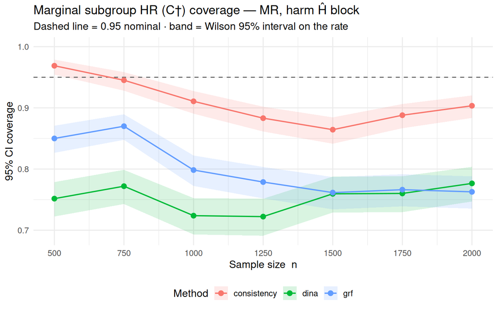

```r
target_pick    <- "C_dagger"   # "C_dagger" (θ†, marginal HR) | "C_ddagger" (θ‡, CDE) | "C_oracle"
estimator_pick <- "MR"         # "MR" | "naive" | "oracle"
block_pick     <- "H"          # "H" | "Hc"
band           <- "wilson"     # "wilson" | "mc_se" | "none"

if (have_grid) {
  pretty_tgt <- c(C_dagger = "Marginal subgroup HR (C\u2020)",
                  C_ddagger = "CDE (C\u2021)",
                  C_oracle = "Per-replicate oracle")[[target_pick]]
  sl <- subset(grid$coverage, target == target_pick &
                              estimator == estimator_pick & block == block_pick)
  sl <- sl[order(sl$n_sample), ]

  if (nrow(sl)) {
    p <- ggplot(sl, aes(n_sample, coverage, colour = subgroup_method,
                        fill = subgroup_method, group = subgroup_method))
    if (band == "wilson")
      p <- p + geom_ribbon(aes(ymin = wilson_lo, ymax = wilson_hi), alpha = 0.15, colour = NA)
    if (band == "mc_se")
      p <- p + geom_ribbon(aes(ymin = coverage - mc_se, ymax = coverage + mc_se),
                           alpha = 0.15, colour = NA)
    y_lo <- min(0.85, min(sl$wilson_lo, sl$coverage, na.rm = TRUE))
    print(
      p + geom_hline(yintercept = 0.95, linetype = 2, colour = "grey40") +
        geom_line(linewidth = 0.7) + geom_point(size = 2.4) +
        scale_x_continuous(breaks = sort(unique(sl$n_sample))) +
        coord_cartesian(ylim = c(y_lo, 1.0)) +
        labs(x = "Sample size  n", y = "95% CI coverage",
             colour = "Method", fill = "Method",
             title = sprintf("%s coverage — %s, %s block", pretty_tgt, estimator_pick,
                             if (block_pick == "H") "harm \u0124" else "complement \u0124\u1d9c"),
             subtitle = "Dashed line = 0.95 nominal · band = Wilson 95% interval on the rate") +
        theme_minimal(base_size = 12) + theme(legend.position = "bottom"))
  } else {
    cat("No rows for the chosen slice yet.\n")
  }
}
```

```r
if (have_grid && exists("sl") && nrow(sl)) {
  disp <- sl[, c("subgroup_method", "n_sample", "coverage", "mc_se",
                 "wilson_lo", "wilson_hi", "n_eff", "n_detected", "det_rate")]
  for (cc in c("coverage", "mc_se", "wilson_lo", "wilson_hi", "det_rate"))
    disp[[cc]] <- round(disp[[cc]], 3)
  knitr::kable(disp, row.names = FALSE,
               caption = sprintf("%s · %s estimator · %s block.",
                                 target_pick, estimator_pick, block_pick))
}
```

C_dagger · MR estimator · H block.

| subgroup_method | n_sample | coverage | mc_se | wilson_lo | wilson_hi | n_eff | n_detected | det_rate |
| --- | --- | --- | --- | --- | --- | --- | --- | --- |
| consistency | 500 | 0.969 | 0.006 | 0.954 | 0.979 | 801 | 801 | 0.801 |
| dina | 500 | 0.752 | 0.014 | 0.722 | 0.779 | 906 | 906 | 0.906 |
| grf | 500 | 0.850 | 0.011 | 0.827 | 0.871 | 1000 | 1000 | 1.000 |
| consistency | 750 | 0.945 | 0.008 | 0.928 | 0.958 | 875 | 875 | 0.875 |
| dina | 750 | 0.772 | 0.014 | 0.743 | 0.799 | 864 | 865 | 0.865 |
| grf | 750 | 0.870 | 0.011 | 0.848 | 0.889 | 1000 | 1000 | 1.000 |
| consistency | 1000 | 0.911 | 0.009 | 0.890 | 0.927 | 918 | 918 | 0.918 |
| dina | 1000 | 0.724 | 0.015 | 0.693 | 0.753 | 869 | 871 | 0.871 |
| grf | 1000 | 0.798 | 0.013 | 0.772 | 0.822 | 997 | 997 | 0.997 |
| consistency | 1250 | 0.883 | 0.010 | 0.861 | 0.902 | 967 | 967 | 0.967 |
| dina | 1250 | 0.722 | 0.015 | 0.691 | 0.752 | 839 | 840 | 0.840 |
| grf | 1250 | 0.779 | 0.013 | 0.752 | 0.803 | 999 | 999 | 0.999 |
| consistency | 1500 | 0.864 | 0.011 | 0.841 | 0.884 | 973 | 973 | 0.973 |
| dina | 1500 | 0.760 | 0.015 | 0.729 | 0.788 | 811 | 814 | 0.814 |
| grf | 1500 | 0.762 | 0.013 | 0.734 | 0.787 | 998 | 998 | 0.998 |
| consistency | 1750 | 0.888 | 0.010 | 0.867 | 0.906 | 982 | 982 | 0.982 |
| dina | 1750 | 0.760 | 0.015 | 0.730 | 0.788 | 813 | 814 | 0.814 |
| grf | 1750 | 0.766 | 0.013 | 0.739 | 0.792 | 997 | 997 | 0.997 |
| consistency | 2000 | 0.903 | 0.009 | 0.883 | 0.920 | 994 | 994 | 0.994 |
| dina | 2000 | 0.777 | 0.014 | 0.747 | 0.804 | 828 | 829 | 0.829 |
| grf | 2000 | 0.763 | 0.013 | 0.735 | 0.788 | 999 | 999 | 0.999 |

## 9.1 95% CI length vs sample size

Median width of the 95% CI for the chosen estimator/block as a function of *n* (median is robust to the occasional IJ blow-up; the band is the interquartile range across replicates). Same `estimator_pick` / `block_pick` as above; length is target-independent, so it has no C†/C‡ axis.

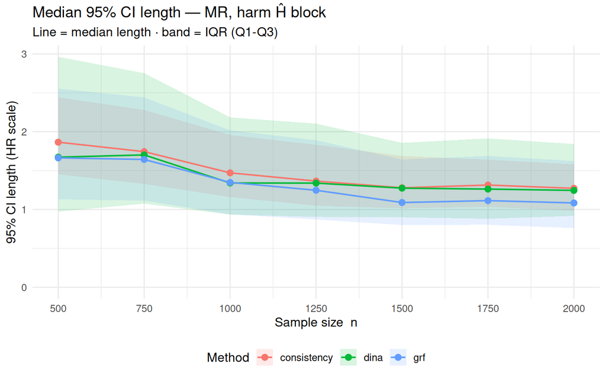

```r
if (have_grid && !is.null(grid$length)) {
  sl_len <- subset(grid$length, estimator == estimator_pick & block == block_pick)
  sl_len <- sl_len[order(sl_len$subgroup_method, sl_len$n_sample), ]
  if (nrow(sl_len)) {
    print(
      ggplot(sl_len, aes(n_sample, len_med, colour = subgroup_method,
                         fill = subgroup_method, group = subgroup_method)) +
        geom_ribbon(aes(ymin = len_q25, ymax = len_q75), alpha = 0.15, colour = NA) +
        geom_line(linewidth = 0.7) + geom_point(size = 2.4) +
        scale_x_continuous(breaks = sort(unique(sl_len$n_sample))) +
        expand_limits(y = 0) +
        labs(x = "Sample size  n", y = "95% CI length (HR scale)",
             colour = "Method", fill = "Method",
             title = sprintf("Median 95%% CI length — %s, %s block", estimator_pick,
                             if (block_pick == "H") "harm \u0124" else "complement \u0124\u1d9c"),
             subtitle = "Line = median length · band = IQR (Q1-Q3)") +
        theme_minimal(base_size = 12) + theme(legend.position = "bottom"))
  } else cat("No rows for the chosen length slice yet.\n")
}
```

## 9.2 Detection rate (companion)

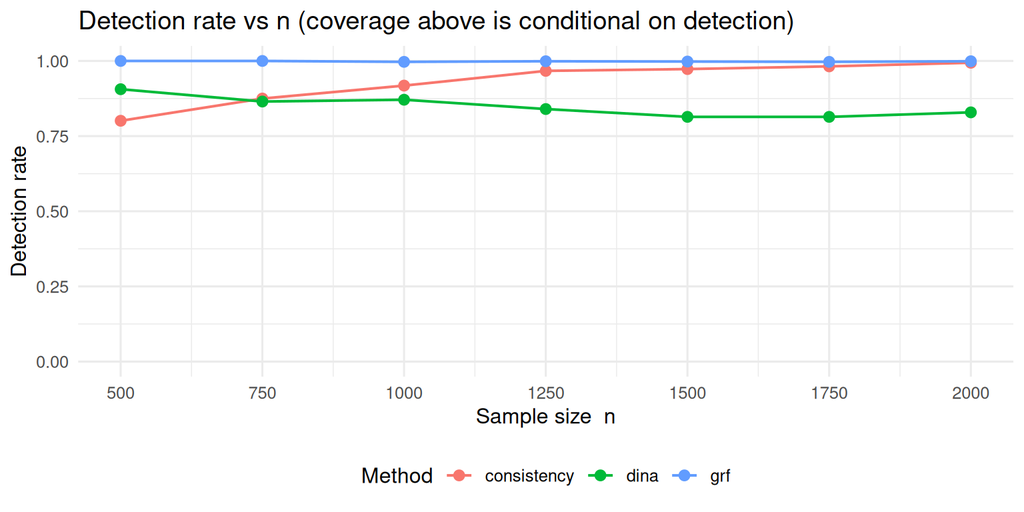

```r
if (have_grid) {
  print(
    ggplot(grid$manifest, aes(n_sample, det_rate, colour = subgroup_method,
                              group = subgroup_method)) +
      geom_line(linewidth = 0.7) + geom_point(size = 2.4) +
      scale_x_continuous(breaks = sort(unique(grid$manifest$n_sample))) +
      coord_cartesian(ylim = c(0, 1)) +
      labs(x = "Sample size  n", y = "Detection rate", colour = "Method",
           title = "Detection rate vs n (coverage above is conditional on detection)") +
      theme_minimal(base_size = 12) + theme(legend.position = "bottom"))
}
```

```r
if (have_grid) {
  cat(sprintf("Grid built %s from %d cell(s).\n", format(grid$built), nrow(grid$manifest)))
  knitr::kable(grid$manifest, row.names = FALSE, caption = "Cells ingested.")
}
```

```
Grid built 2026-06-21 11:33:49 from 21 cell(s).
```

Cells ingested.

| file | subgroup_method | n_sample | n_sims | n_detected | det_rate | gate_draws | nb_boots | seed_base |
| --- | --- | --- | --- | --- | --- | --- | --- | --- |
| fs_mr_consistency_n500_res.rds | consistency | 500 | 1000 | 801 | 0.801 | 5000 | NA | 8316951 |
| fs_mr_consistency_n750_res.rds | consistency | 750 | 1000 | 875 | 0.875 | 5000 | NA | 8316951 |
| fs_mr_consistency_n1000_res.rds | consistency | 1000 | 1000 | 918 | 0.918 | 5000 | NA | 8316951 |
| fs_mr_consistency_n1250_res.rds | consistency | 1250 | 1000 | 967 | 0.967 | 5000 | NA | 8316951 |
| fs_mr_consistency_n1500_res.rds | consistency | 1500 | 1000 | 973 | 0.973 | 5000 | NA | 8316951 |
| fs_mr_consistency_n1750_res.rds | consistency | 1750 | 1000 | 982 | 0.982 | 5000 | NA | 8316951 |
| fs_mr_consistency_n2000_res.rds | consistency | 2000 | 1000 | 994 | 0.994 | 5000 | NA | 8316951 |
| fs_mr_dina_n500_res.rds | dina | 500 | 1000 | 906 | 0.906 | 5000 | NA | 8316951 |
| fs_mr_dina_n750_res.rds | dina | 750 | 1000 | 865 | 0.865 | 5000 | NA | 8316951 |
| fs_mr_dina_n1000_res.rds | dina | 1000 | 1000 | 871 | 0.871 | 5000 | NA | 8316951 |
| fs_mr_dina_n1250_res.rds | dina | 1250 | 1000 | 840 | 0.840 | 5000 | NA | 8316951 |
| fs_mr_dina_n1500_res.rds | dina | 1500 | 1000 | 814 | 0.814 | 5000 | NA | 8316951 |
| fs_mr_dina_n1750_res.rds | dina | 1750 | 1000 | 814 | 0.814 | 5000 | NA | 8316951 |
| fs_mr_dina_n2000_res.rds | dina | 2000 | 1000 | 829 | 0.829 | 5000 | NA | 8316951 |
| fs_mr_grf_n500_res.rds | grf | 500 | 1000 | 1000 | 1.000 | 5000 | NA | 8316951 |
| fs_mr_grf_n750_res.rds | grf | 750 | 1000 | 1000 | 1.000 | 5000 | NA | 8316951 |
| fs_mr_grf_n1000_res.rds | grf | 1000 | 1000 | 997 | 0.997 | 5000 | NA | 8316951 |
| fs_mr_grf_n1250_res.rds | grf | 1250 | 1000 | 999 | 0.999 | 5000 | NA | 8316951 |
| fs_mr_grf_n1500_res.rds | grf | 1500 | 1000 | 998 | 0.998 | 5000 | NA | 8316951 |
| fs_mr_grf_n1750_res.rds | grf | 1750 | 1000 | 997 | 0.997 | 5000 | NA | 8316951 |
| fs_mr_grf_n2000_res.rds | grf | 2000 | 1000 | 999 | 0.999 | 5000 | NA | 8316951 |

```r
if (!is.null(sweep_log)) {
  cat("\nThis render's sweep activity:\n")
  knitr::kable(sweep_log, row.names = FALSE, caption = "Per-cell run status this render.")
}
```

# 10 Session info

```r
.fmt_dur <- function(s) {
  h <- s %/% 3600; m <- (s %% 3600) %/% 60; sec <- round(s %% 60)
  if (h >= 1) sprintf("%d h %02d m %02d s", h, m, sec)
  else if (m >= 1) sprintf("%d m %02d s", m, sec) else sprintf("%.1f s", s)
}
cat(sprintf("TOTAL wall-clock, start to finish: %s\n",
            .fmt_dur(as.numeric(difftime(Sys.time(), .t0_doc, units = "secs")))))
```

```
TOTAL wall-clock, start to finish: 3.7 s
```